# Classes

Classes are extended data types either defined by the people who maintain R, or us, the humble users. There are at least three different ways of defining classes in R (`s3`, `s4`, `Reference classes`). We only look at `s3` here, as they are the most simple (if a bit weird).

## Built-in classes

A good example of a class is `data.frame`, which we will see is a glorified `list` with extra attributes.

```r
# making a data frame
d <- data.frame(a = 1:10, b = 11:20, c = 21:30)
# we can check the class with class()
dcl <- class(d)
cat("The class of data frame is:", dcl, "\n")
```

```
## The class of data frame is: data.frame
```

```r
# check the type of this data frame
typd <- typeof(d)
cat("The type of a data frame is:", typd, "\n")
```

```
## The type of a data frame is: list
```

We can see all of the so-called ‘methods’ associated with this class. Methods are functions which have specific behavior based on the class of object they are called on.

```r
methods(class = class(d))
```

```
##  [1] [             [[            [[<-          [<-           $<-
##  [6] aggregate     anyDuplicated anyNA         as.data.frame as.list
## [11] as.matrix     as.vector     by            cbind         coerce
## [16] dim           dimnames      dimnames<-    droplevels    duplicated
## [21] edit          format        formula       head          initialize
## [26] is.na         Math          merge         na.exclude    na.omit
## [31] Ops           plot          print         prompt        rbind
## [36] row.names     row.names<-   rowsum        show          slotsFromS3
## [41] split         split<-       stack         str           subset
## [46] summary       Summary       t             tail          transform
## [51] type.convert  unique        unstack       within        xtfrm
## see '?methods' for accessing help and source code
```

There are actually loads of functions which have specific behavior when called on `data.frame` - that’s interesting.

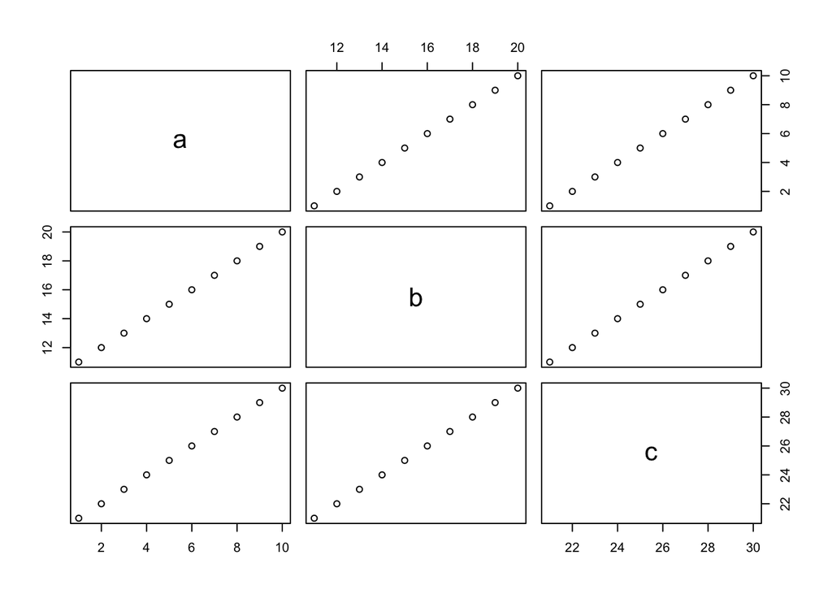

```r
# we produce quite a weird plot which attempts to plot each pairwise
# combination of columns
plot(d)
```

However if we have another class which implements the `plot` method, such as `table`, we can see the difference. So even though the function call is the same (`plot()`) the results from the function depend on the class of the object the function is being called on. This is good to keep in mind as you go through your R journey, as otherwise some function calls might catch you off guard.

```r
# table is a useful function that makes frequency tables in R
methods(class = "table")
```

```
##  [1] [             aperm         as.data.frame Axis          coerce
##  [6] initialize    lines         plot          points        print
## [11] show          slotsFromS3   summary       tail
## see '?methods' for accessing help and source code
```

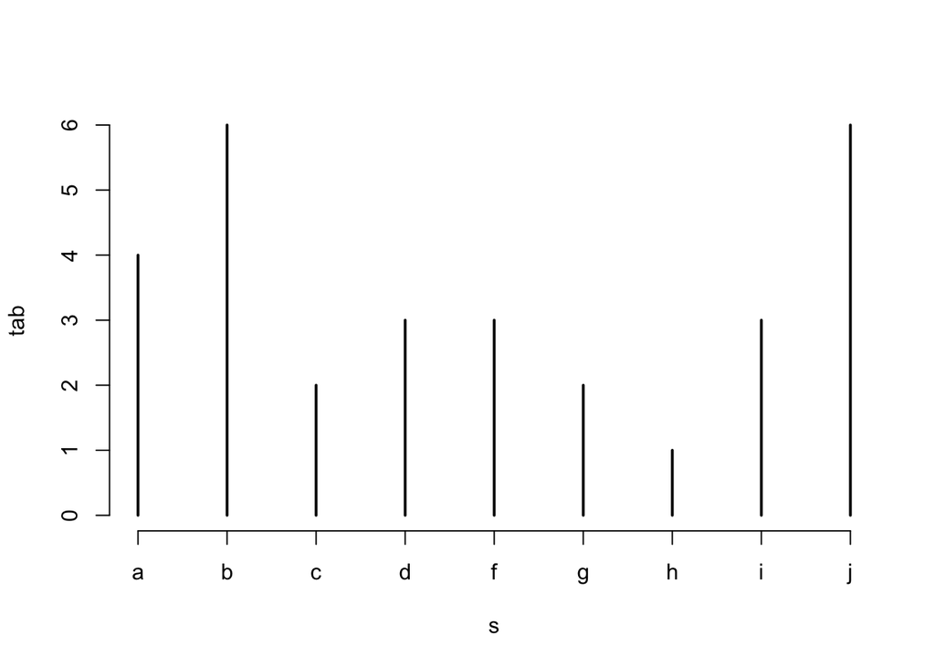

```r
# sample 30 numbers from the range 1:1000
s <- sample(letters[1:10], 30, replace = TRUE)
# create a frequency table of the letters
tab <- table(s)
# and plot
plot(tab)
```

## Making our own classes

While the in built classes are useful and interesting, we can also create our own classes. I think this is quite an advanced topic, and pretty abstract. Therefore this section will be brief, and I suggest come back to this later in the course. I’ve put it here because they are data types, and they are important.

Classes are best created using `structure`.

```r
# this is one way of doing it
# it's really a wrapper around a vector
red <- structure(c(), class = "red")

# it's better to provide what's called a constructor function
# which is used to create the object.
red <- function(vec) {
  if (!is.numeric(vec) & !is.vector(vec)) stop("input should be a numeric vector")

  structure(vec, class = "red")
}

# now we can call our new class!
vec <- c(1, 3, 2, 5, 3, 4, 5)

# should print out the class
red(vec)
```

```
## [1] 1 3 2 5 3 4 5
## attr(,"class")
## [1] "red"
```

And we can make a generic method like this. Again, this is pretty advanced stuff, and many people never make classes. They are a lovely way to organise your code though. We can make specific methods like this.

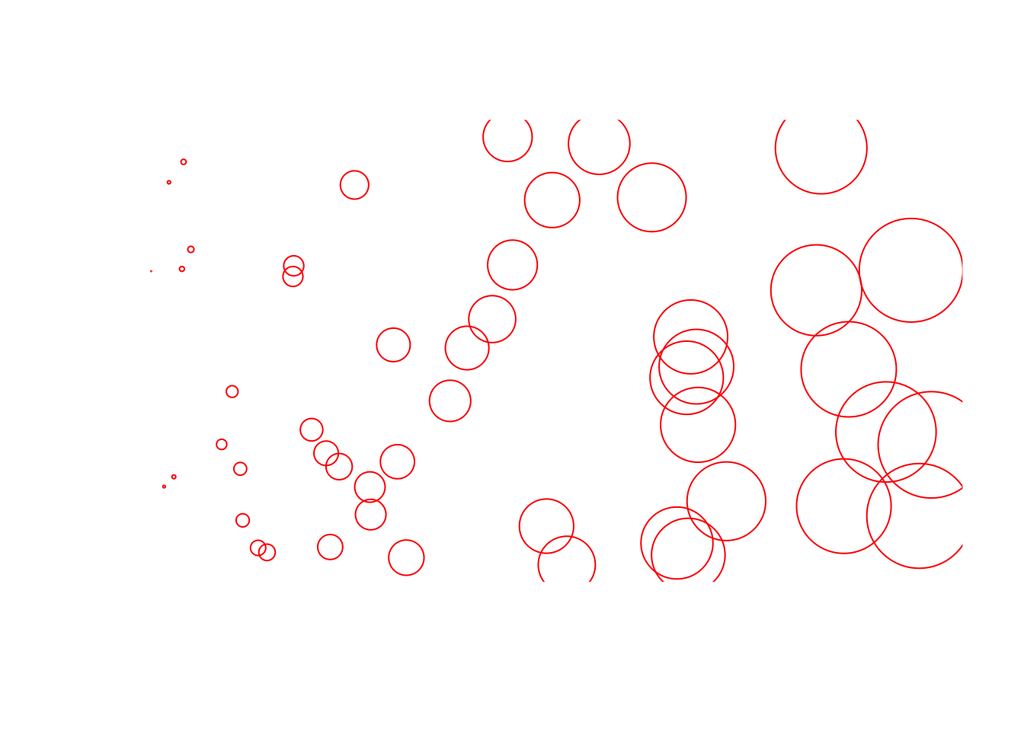

```r
# I just made this up, so roll with it
plot.red <- function(red) {
  # inside our method, we are calling the generic
  # plot function, plot.default
  plot.default(
    # the data on the x
    red,
    # randomly reordered data on the y
    red[sample(length(red), length(red))],
    # obviously colour everything red
    col = "red",
    # control the size of the points based
    # on the value of the point, and scale
    cex = red / 100,
    # remove x, y axes and labels
    xaxt = "n",
    yaxt = "n",
    ylab = "",
    xlab = "",
    bty = "n"
  )
}

# make up some data, 50 numbers from the range 1:1000
red_data <- red(sample(1:1000, 50))

# and call the generic plot function again!
plot(red_data)
```

## Over to you

1. List all the methods in the `formula` class.
2. How many are there? Hint: use the `length` function.
3. Create a new class with a class name of your choice.
4. Implement a generic function for your class.